# Lab#9

Ifeoma Okonye

2024-04-02

## Introduction

For this lab, I used the raster, sf and tidyverse packages. The datalayers I made use of are the 2019 Cropland Data Layer (CDL) for Riley county and elevation data. I did some data tidying by converting the 0 values in the landuse data to NA and then I converted both dataset (CDL and elevation) to the right coordinate reference system.

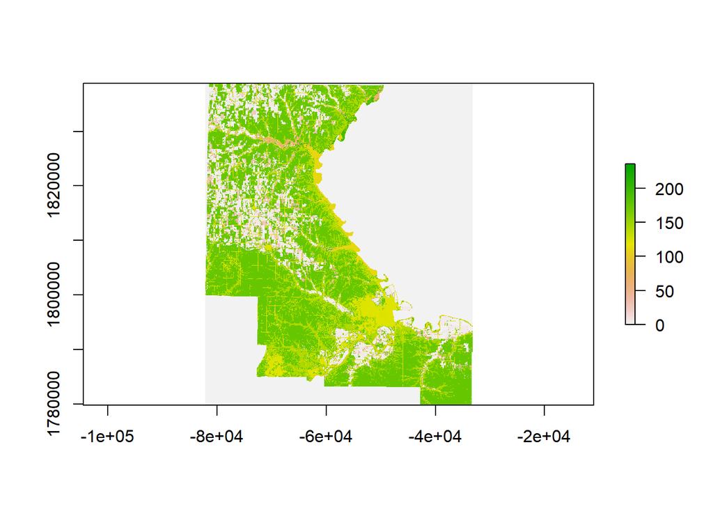

```r
library(pacman)
p_load(raster, sf, tidyverse)


riley <- raster("CDL_2019_20161.tif")
elev <- raster("elevation.tif")


plot(riley)
```

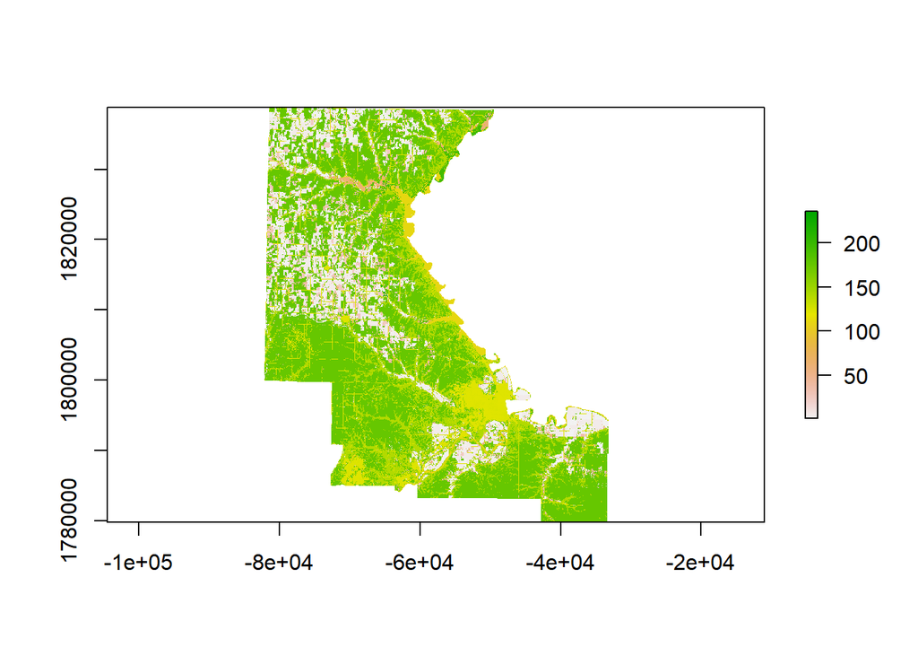

```r
riley[riley == 0] <- NA

plot(riley)
```

```r
crs(riley)
```

```
## Coordinate Reference System:
## Deprecated Proj.4 representation:
##  +proj=aea +lat_0=23 +lon_0=-96 +lat_1=29.5 +lat_2=45.5 +x_0=0 +y_0=0
## +datum=NAD83 +units=m +no_defs
## WKT2 2019 representation:
## PROJCRS["unknown",
##     BASEGEOGCRS["unknown",
##         DATUM["North American Datum 1983",
##             ELLIPSOID["GRS 1980",6378137,298.257222101,
##                 LENGTHUNIT["metre",1]],
##             ID["EPSG",6269]],
##         PRIMEM["Greenwich",0,
##             ANGLEUNIT["degree",0.0174532925199433],
##             ID["EPSG",8901]]],
##     CONVERSION["unknown",
##         METHOD["Albers Equal Area",
##             ID["EPSG",9822]],
##         PARAMETER["Latitude of false origin",23,
##             ANGLEUNIT["degree",0.0174532925199433],
##             ID["EPSG",8821]],
##         PARAMETER["Longitude of false origin",-96,
##             ANGLEUNIT["degree",0.0174532925199433],
##             ID["EPSG",8822]],
##         PARAMETER["Latitude of 1st standard parallel",29.5,
##             ANGLEUNIT["degree",0.0174532925199433],
##             ID["EPSG",8823]],
##         PARAMETER["Latitude of 2nd standard parallel",45.5,
##             ANGLEUNIT["degree",0.0174532925199433],
##             ID["EPSG",8824]],
##         PARAMETER["Easting at false origin",0,
##             LENGTHUNIT["metre",1],
##             ID["EPSG",8826]],
##         PARAMETER["Northing at false origin",0,
##             LENGTHUNIT["metre",1],
##             ID["EPSG",8827]]],
##     CS[Cartesian,2],
##         AXIS["(E)",east,
##             ORDER[1],
##             LENGTHUNIT["metre",1,
##                 ID["EPSG",9001]]],
##         AXIS["(N)",north,
##             ORDER[2],
##             LENGTHUNIT["metre",1,
##                 ID["EPSG",9001]]]]
```

```r
crs(elev)
```

```
## Coordinate Reference System:
## Deprecated Proj.4 representation: +proj=longlat +datum=NAD83 +no_defs
## WKT2 2019 representation:
## GEOGCRS["unknown",
##     DATUM["North American Datum 1983",
##         ELLIPSOID["GRS 1980",6378137,298.257222101,
##             LENGTHUNIT["metre",1]],
##         ID["EPSG",6269]],
##     PRIMEM["Greenwich",0,
##         ANGLEUNIT["degree",0.0174532925199433],
##         ID["EPSG",8901]],
##     CS[ellipsoidal,2],
##         AXIS["longitude",east,
##             ORDER[1],
##             ANGLEUNIT["degree",0.0174532925199433,
##                 ID["EPSG",9122]]],
##         AXIS["latitude",north,
##             ORDER[2],
##             ANGLEUNIT["degree",0.0174532925199433,
##                 ID["EPSG",9122]]]]
```

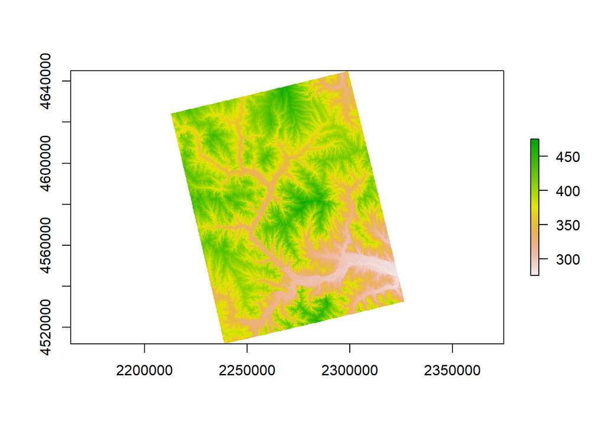

```r
crs <- '+proj=utm +zone=11 +ellps=GRS80 +datum=NAD83 +units=m +no_defs'

riley <- projectRaster(riley, crs = crs, method = "ngb")

elev <- projectRaster(elev, crs = crs, method = "bilinear")

plot(elev)
```

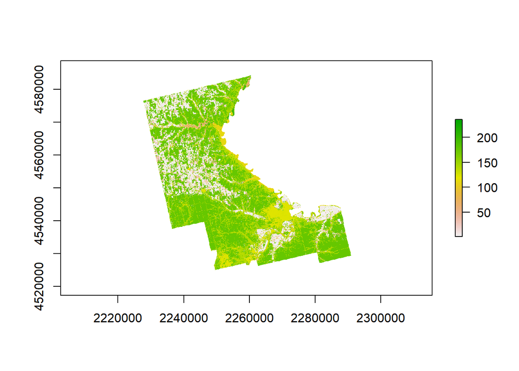

```r
plot(riley)
```

### Question 1

I transformed both raster so that they have a consistent grid structure and aggregated them to a grid cell resolution of 1km x 1km. I then plotted the resampled raster layers.

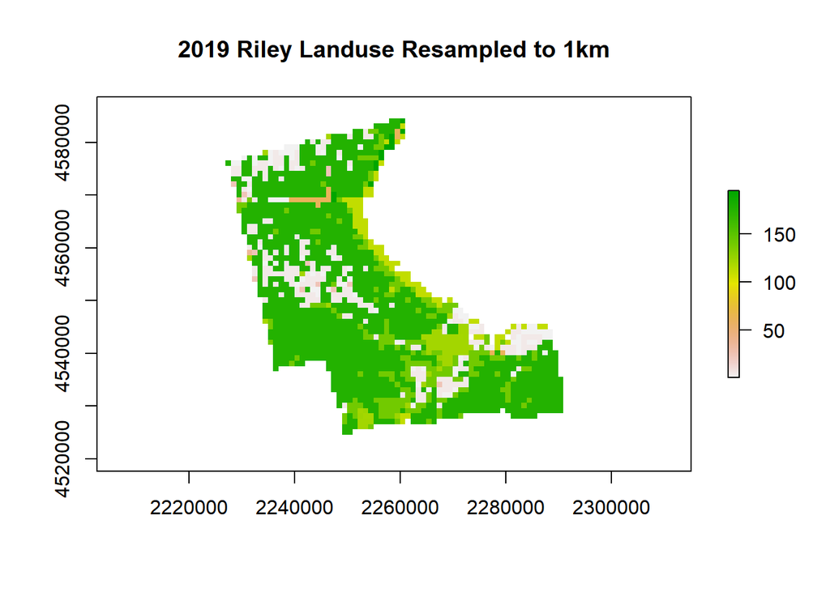

```r
# for croptype 2019 riley data
new_ras_1km <- raster(crs = crs,
                  ext = extent(riley),
                  resolution = c(1000, 1000))


riley_1km <- resample(riley, new_ras_1km,
                                  method = "ngb")

plot(riley_1km, main = "2019 Riley Landuse Resampled to 1km")
```

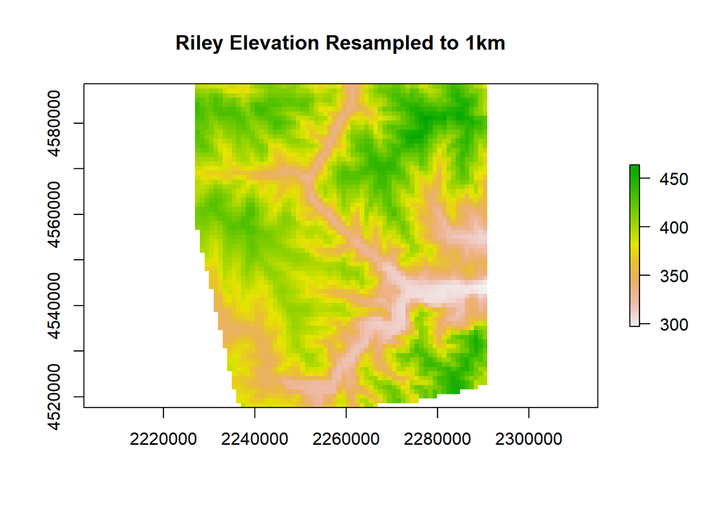

```r
# for elevation data

elevras_1km <- raster(crs = crs,
                  ext = extent(riley),
                  resolution = c(1000, 1000))


elev_1km <- resample(elev, elevras_1km,
                                  method = "bilinear")

plot(elev_1km, main = "Riley Elevation Resampled to 1km")
```

### Question 2

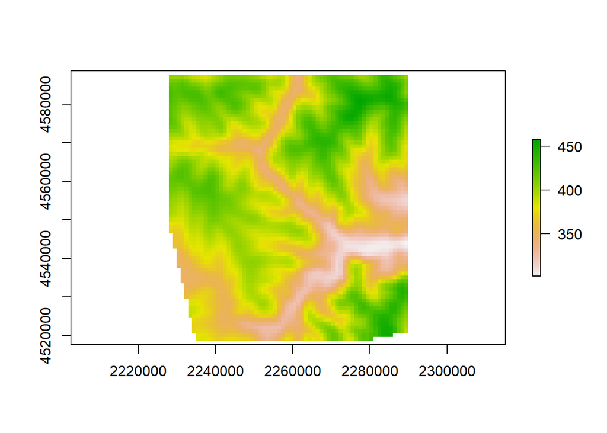

```r
# focal statistics on elevation data

elev_smooth <- focal(elev_1km,
                     w = matrix(1 , ncol = 3, nrow = 3),
                     fun = mean, na.rm = T)
plot(elev_smooth)
```

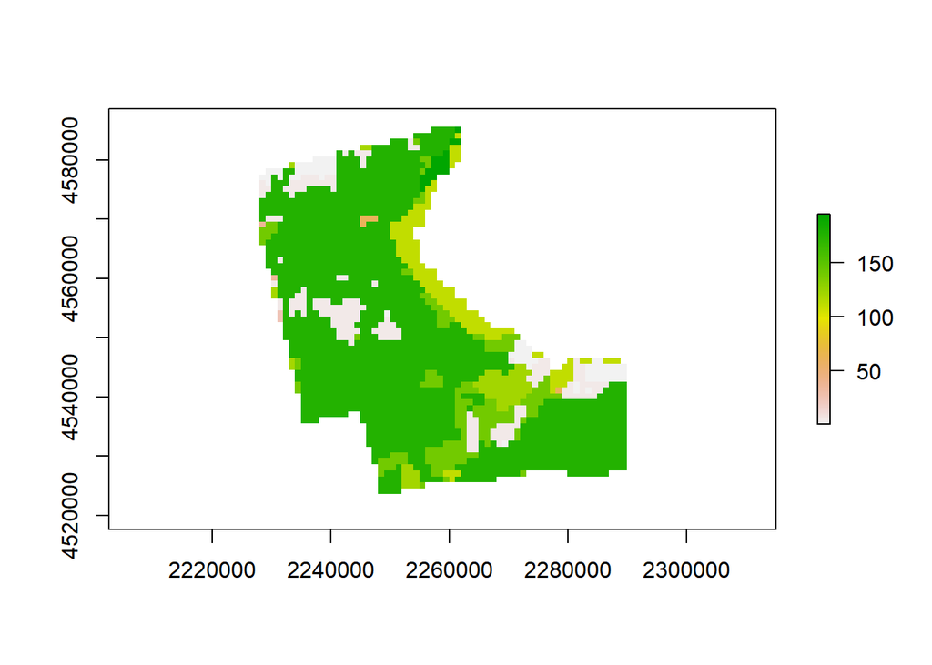

```r
# focal statistics on landuse data

riley_smooth <- focal(riley_1km,
                      w = matrix(1, ncol = 3, nrow = 3),
                      fun = modal, na.rm = T)
plot(riley_smooth)
```

### Question 3

Using the smoothed elevation raster, I calculated and reported the average slope and elevation for each land use type in the raster. The landuse type at the highest elevation is Sorghum (4) at an elevation of 409m and the landuse at the lowest elevation is Open Water (111) at an elevation 0f 339m. This analysis seems to be reasonable as Open Water will be found at lower elevations and crops like Sorghum are found at higher elevations.

For the slope analysis, the slope was was categorized into 4 zones with 4 being the highest slope zone and 1 being the lowest. From the analysis, it is difficult to identify which land use type fall within each zone.

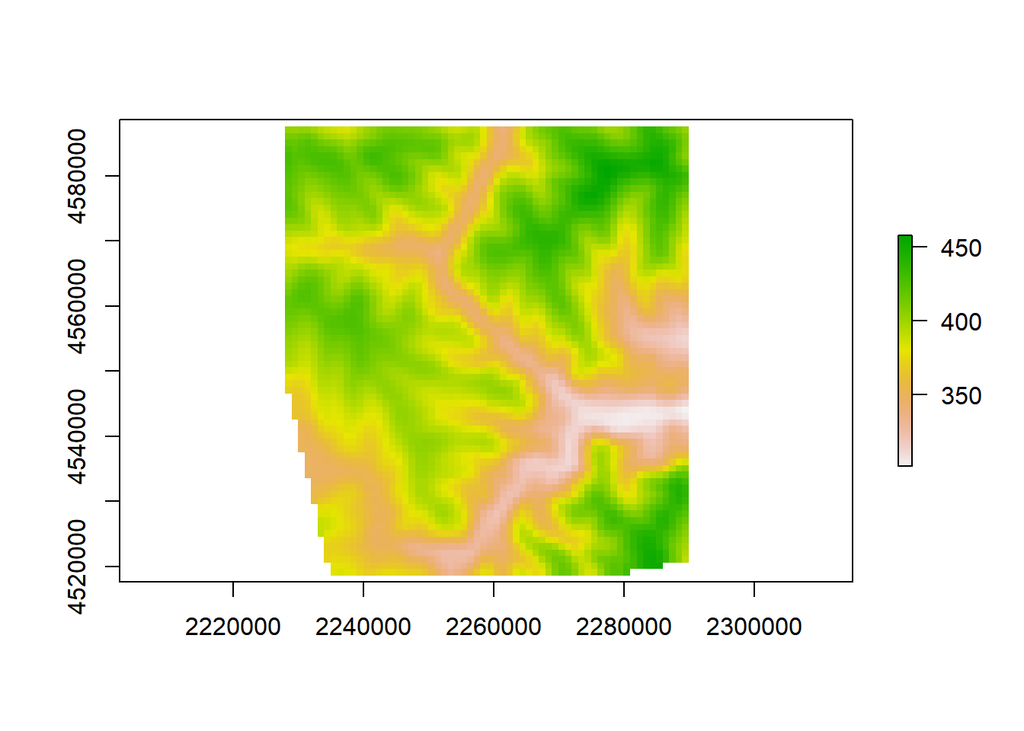

```r
#fix extent
elev_smooth_rc <- crop(elev_smooth, extent(riley_1km))
plot(elev_smooth_rc)
```

```r
#check resolution
res(elev_smooth)
```

```
## [1] 1000 1000
```

```r
res(riley_1km)
```

```
## [1] 1000 1000
```

```r
# zonal op
elev_crop <- zonal(elev_smooth_rc, riley_1km,
                   fun = mean, na.rm=T) %>%
  as.data.frame()
round(elev_crop)
```

```
##    zone value
## 1     1   365
## 2     4   409
## 3     5   378
## 4    24   393
## 5    36   398
## 6    61   351
## 7   111   339
## 8   121   370
## 9   122   342
## 10  123   347
## 11  124   393
## 12  141   358
## 13  142   346
## 14  176   387
## 15  195   347
```

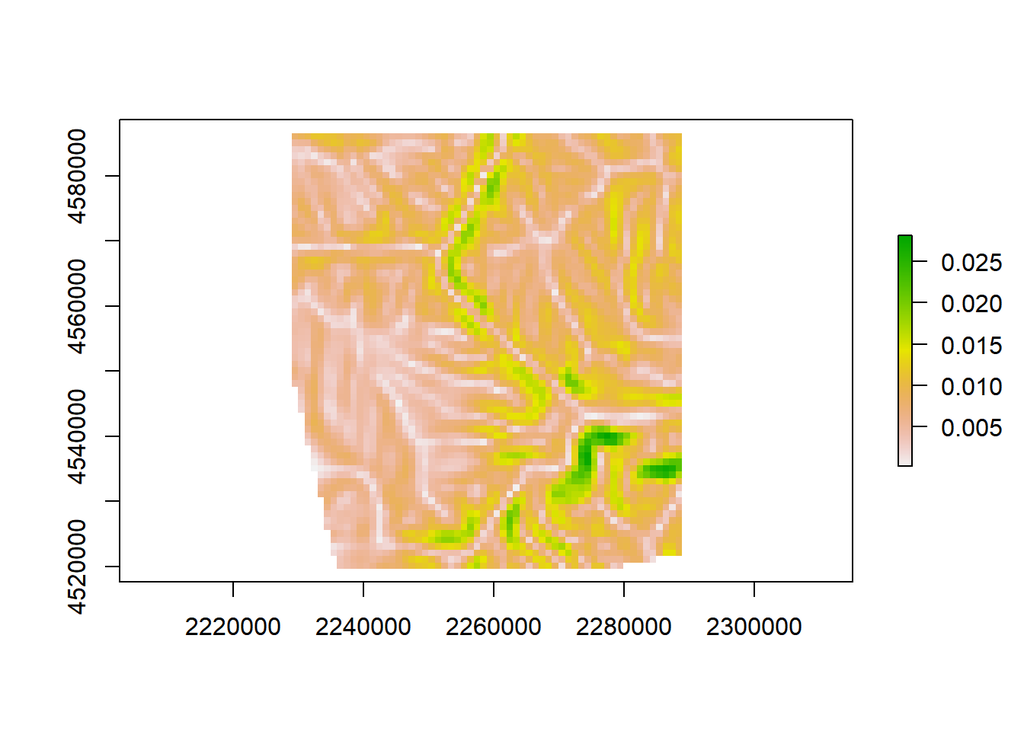

```r
#calculating slope (terrain)
slope <- terrain(elev_smooth_rc,
                 opt = "slope",
                 units = "degrees")

plot(slope)
```

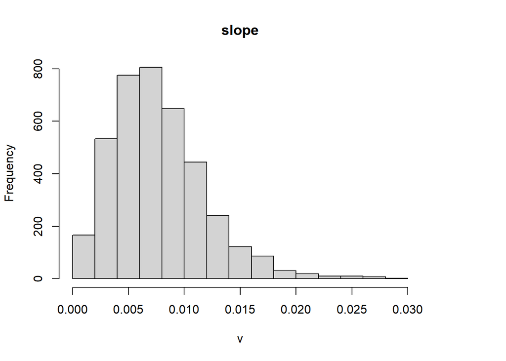

```r
hist(slope)
```

```r
cellStats(slope, stat = min)
```

```
## [1] 0.0002059098
```

```r
cellStats(slope, stat = max)
```

```
## [1] 0.02818044
```

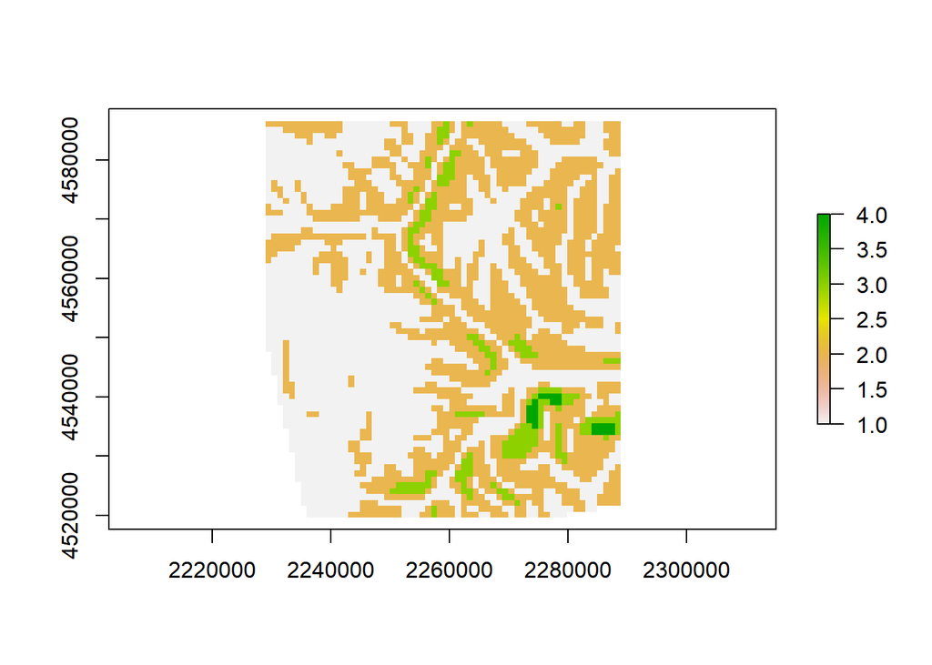

```r
#reclassifying slopes into 4 different zones
zones <- reclassify(slope, c(0.0002, 0.0075, 1,      # From 0.0002 to 0.0075 -> Zone 1
                              0.0075, 0.015, 2,      # From 0.0075 to 0.015 -> Zone 2
                              0.015, 0.0225, 3,      # From 0.015 to 0.0225 -> Zone 3
                               0.0225, 0.03, 4),     # From 0.0225 to 0.03 -> Zone 4
                            byrow = TRUE)

zones <- ratify(zones)
plot(zones)
```

```r
#getting average slope for each landuse type

landuse_slope <- zonal(riley_1km, zones, fun = mean)
landuse_slope
```

```
##      zone    value
## [1,]    1 130.6723
## [2,]    2 149.7903
## [3,]    3 142.1481
## [4,]    4 154.8636
```

### Question 4

I created zones of elevation by quantiles and calculated the average value of landuse diversity in each zone. The trend in the data shows that the fruther you move away from the watershed, the higher the elevation.

```r
LU_Diversity.rc <- focal(riley_1km,
                      w = matrix(1, ncol = 3, nrow = 3),
                      fun = modal, na.rm = T)

#Creating the elevation zones by quantiles
elev_quant <- quantile(values(elev_smooth),
                       probs = c(0, 0.25, 0.50, 0.75, 1.0),
                       na.rm = T)
elev_zones <- raster(elev_smooth)
values(elev_zones) <- cut(values(elev_smooth),
                          breaks = elev_quant, include.lowest = T)

avg_diversity <- zonal(LU_Diversity.rc,
                       elev_zones, fun = mean)
avg_diversity
```

```
##      zone    value
## [1,]    1 119.8041
## [2,]    2 169.6018
## [3,]    3 163.2747
## [4,]    4 126.2718
```

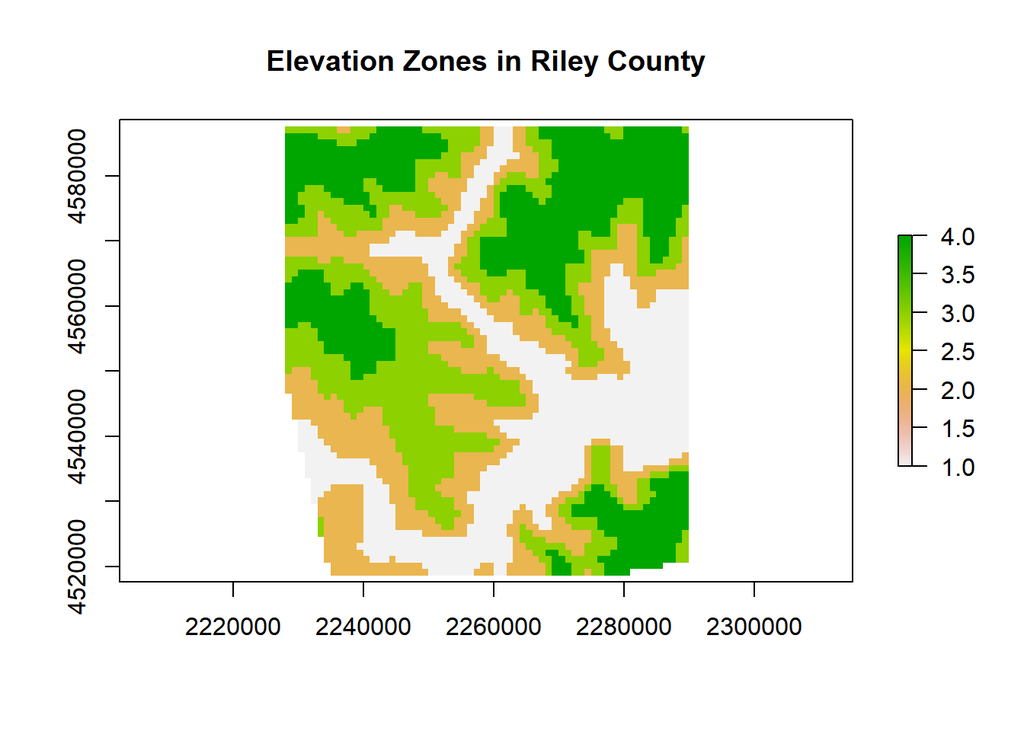

```r
plot(elev_zones, main = "Elevation Zones in Riley County")
```

### Question 5

I finally created a raster displaying the distance from developed areas with the closest distance displayed in white and the farthest shown in green. The units are in meters.

```r
unique(riley_1km)
```

```
##  [1]   1   4   5  24  36  61 111 121 122 123 124 141 142 176 195
```

```r
#reclassify all dev areas to 121
riley_1km <- reclassify(riley_1km, c(120,125, 121))
unique(riley_1km)
```

```
##  [1]   1   4   5  24  36  61 111 121 141 142 176 195
```

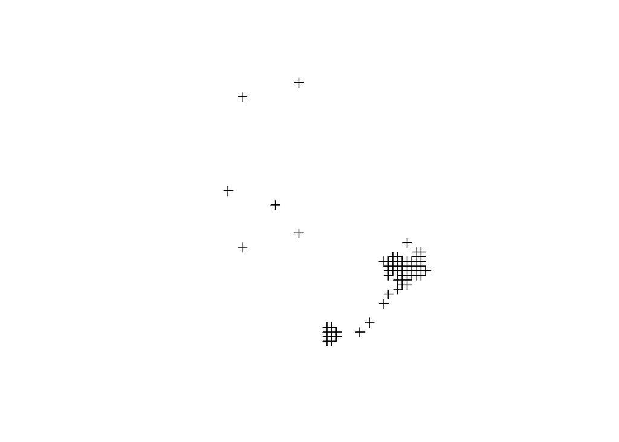

```r
##creating developed area points from the raster
dev_area_pts <- rasterToPoints(riley_1km, fun = function(x) {x==121}, spatial = T)
plot(dev_area_pts)
```

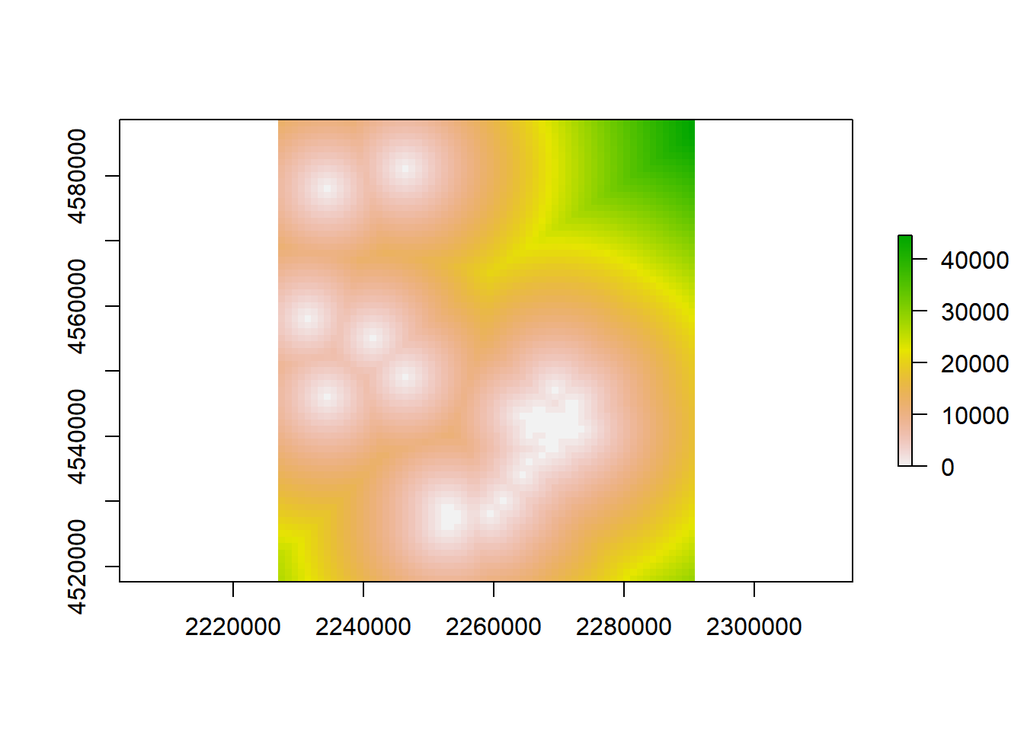

```r
## creating raster showing distance from developed areas
dev_area_dist <- distanceFromPoints(riley_1km, dev_area_pts)
plot(dev_area_dist)
```